# Threat and Demography Scores, Analysis 1

Jacob Malcom, Whitney Webber, Ya-Wei Li

2016-06-14

## Are FWS’s current status metrics sufficient for accurately reflecting the conservation status of ESA-listed species?

### Multinomial models

First, a naive model that assumes the response variable is the threat or demography score, even though this *implies* causality flows the opposite direction.

```r
# Threats and demography by status change
amod <- lm(change$Threat_allev ~ change$status_cat + 0)
summary(amod)
```

```
##
## Call:
## lm(formula = change$Threat_allev ~ change$status_cat + 0)
##
## Residuals:
##     Min      1Q  Median      3Q     Max
## -1.5741 -0.3667  0.1333  0.4259  0.6333
##
## Coefficients:
##                            Estimate Std. Error t value Pr(>|t|)
## change$status_catDegrade   -0.35000    0.15393  -2.274   0.0274 *
## change$status_catImprove    0.57407    0.09368   6.128 1.48e-07 ***
## change$status_catNo Change -0.13333    0.12568  -1.061   0.2939
## ---
## Signif. codes:  0 '***' 0.001 '**' 0.01 '*' 0.05 '.' 0.1 ' ' 1
##
## Residual standard error: 0.4868 on 49 degrees of freedom
## Multiple R-squared:  0.4723, Adjusted R-squared:   0.44
## F-statistic: 14.62 on 3 and 49 DF,  p-value: 6.297e-07
```

```r
bmod <- lm(change$Improve_demo ~ change$status_cat + 0)
summary(bmod)
```

```
##
## Call:
## lm(formula = change$Improve_demo ~ change$status_cat + 0)
##
## Residuals:
##      Min       1Q   Median       3Q      Max
## -1.59259 -0.10000  0.03704  0.40741  1.16667
##
## Coefficients:
##                            Estimate Std. Error t value Pr(>|t|)
## change$status_catDegrade    -0.9000     0.1705  -5.277 2.97e-06 ***
## change$status_catImprove     0.5926     0.1038   5.710 6.54e-07 ***
## change$status_catNo Change  -0.1667     0.1392  -1.197    0.237
## ---
## Signif. codes:  0 '***' 0.001 '**' 0.01 '*' 0.05 '.' 0.1 ' ' 1
##
## Residual standard error: 0.5393 on 49 degrees of freedom
## Multiple R-squared:  0.5581, Adjusted R-squared:  0.531
## F-statistic: 20.63 on 3 and 49 DF,  p-value: 8.799e-09
```

```r
cmod <- lm(change$combined_components ~ change$status_cat + 0)
summary(cmod)
```

```
##
## Call:
## lm(formula = change$combined_components ~ change$status_cat +
##     0)
##
## Residuals:
##     Min      1Q  Median      3Q     Max
## -2.1667 -0.3542  0.2500  0.3333  1.8000
##
## Coefficients:
##                            Estimate Std. Error t value Pr(>|t|)
## change$status_catDegrade    -1.2500     0.2327  -5.373 2.13e-06 ***
## change$status_catImprove     1.1667     0.1416   8.239 8.24e-11 ***
## change$status_catNo Change  -0.3000     0.1900  -1.579    0.121
## ---
## Signif. codes:  0 '***' 0.001 '**' 0.01 '*' 0.05 '.' 0.1 ' ' 1
##
## Residual standard error: 0.7357 on 49 degrees of freedom
## Multiple R-squared:  0.6695, Adjusted R-squared:  0.6492
## F-statistic: 33.08 on 3 and 49 DF,  p-value: 7.785e-12
```

But the response is actually FWS’s recommended status change, which should be a function of threat and demographic status. This requires using multinomial models. Because we are interested in the relationship between threat and demography scores individually and combined, we consider four models:

```r
change$status_cat <- relevel(factor(change$status_cat), ref="No Change")
combo_mod <- nnet::multinom(status_cat ~ 0 + combined_components,
                            data = change,
                            trace = FALSE)
combo_p <- get_multinom_p(combo_mod)

thr_demo_mod <- nnet::multinom(status_cat ~ 0 + Threat_allev + Improve_demo,
                               data = change,
                               trace = FALSE)
thr_demo_p <- get_multinom_p(thr_demo_mod)

thr_mod <- nnet::multinom(status_cat ~ 0 + Threat_allev,
                          data = change,
                          trace = FALSE)
thr_p <- get_multinom_p(thr_mod)

demo_mod <- nnet::multinom(status_cat ~ 0 + Improve_demo,
                           data = change,
                           trace = FALSE)
demo_p <- get_multinom_p(demo_mod)

AICcmodavg::aictab(list(combo_mod, thr_demo_mod, thr_mod, demo_mod))
```

```
##
## Model selection based on AICc:
##
##      K  AICc Delta_AICc AICcWt Cum.Wt     LL
## Mod1 2 68.77       0.00   0.86   0.86 -32.26
## Mod2 4 72.38       3.61   0.14   1.00 -31.76
## Mod4 2 82.54      13.77   0.00   1.00 -39.15
## Mod3 2 84.14      15.37   0.00   1.00 -39.95
```

Model 1 (threat and demography scores added for a single predictor) is the most parsimonious model given the data. The details of the model are:

```
## Call:
## nnet::multinom(formula = status_cat ~ 0 + combined_components,
##     data = change, trace = FALSE)
##
## Coefficients:
##         combined_components
## Degrade          -0.5779225
## Improve           2.2791230
##
## Std. Errors:
##         combined_components
## Degrade           0.4044546
## Improve           0.6307760
##
## Residual Deviance: 64.52339
## AIC: 68.52339
```

```
## p-values:
```

```
##         combined_components
## Degrade        0.1530348446
## Improve        0.0003024356
```

```
## Call:
## nnet::multinom(formula = status_cat ~ 0 + Threat_allev + Improve_demo,
##     data = change, trace = FALSE)
##
## Coefficients:
##         Threat_allev Improve_demo
## Degrade  -0.07025598   -0.8765509
## Improve   2.99045553    1.8492412
##
## Std. Errors:
##         Threat_allev Improve_demo
## Degrade    0.7865271    0.5697880
## Improve    1.0625764    0.7816666
##
## Residual Deviance: 63.52684
## AIC: 71.52684
```

```
## p-values:
```

```
##         Threat_allev Improve_demo
## Degrade  0.928824184   0.12395551
## Improve  0.004887689   0.01799276
```

We can plot the data by FWS recommendation and threat and demography scores to ‘see’ how things shake out:

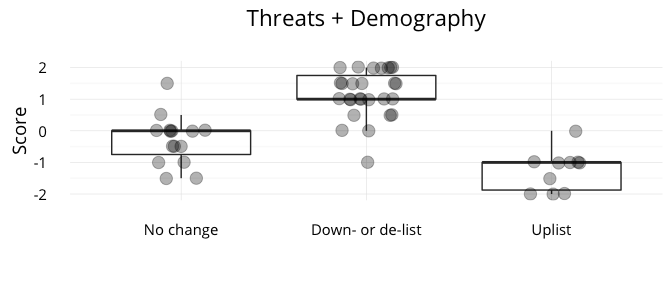

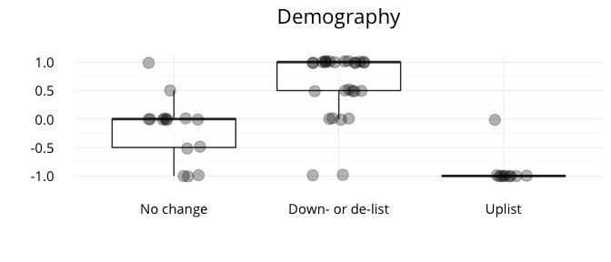

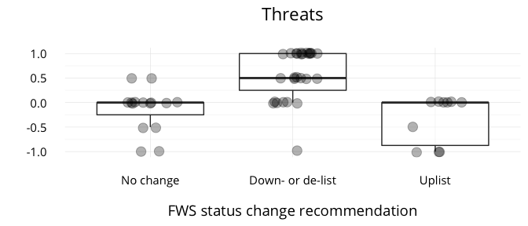

This basically comports with the multinomial models: there is some predictability of FWS status change recommendations, but those recommendations don’t always seem to be consistent with threats and demography individually.

### Discriminant function analysis

The second evaluation of whether FWS’s status change recommendations are consistent with threat and demography change scores is done with discriminant function analysis (or linear discriminant analysis). We consider the same four model structures as with the multinomial models.

```r
dfa_combo <- MASS::lda(status_cat ~ combined_components,
                       data = change,
                       na.action = "na.omit",
                       CV=TRUE)
combo_comps <- get_lda_comps(change, dfa_combo)

dfa_both <- MASS::lda(status_cat ~ Threat_allev + Improve_demo,
                      data = change,
                      na.action = "na.omit",
                      CV=TRUE)
both_comps <- get_lda_comps(change, dfa_both)

dfa_threat <- MASS::lda(status_cat ~ Threat_allev,
                        data = change,
                        na.action = "na.omit",
                        CV=TRUE)
thr_comps <- get_lda_comps(change, dfa_threat)

dfa_demog <- MASS::lda(status_cat ~ Improve_demo,
                       data = change,
                       na.action = "na.omit",
                       CV=TRUE)
demog_comps <- get_lda_comps(change, dfa_demog)

consists <- c(combo = combo_comps$consistency,
              both = both_comps$consistency,
              threat = thr_comps$consistency,
              demography = demog_comps$consistency)

consists
```

```
##      combo       both     threat demography
##  0.7115385  0.8076923  0.6538462  0.6153846
```

The LDA model using threat and demography scores as separate predictors has the highest consistency. To see the (mis-)classifications, with FWS’s assignment in the columns and the assignment expected given the scores in rows, we have:

```
##
##              No Change    Degrade    Improve
##   No Change 0.60000000 0.10000000 0.03703704
##   Degrade   0.26666667 0.90000000 0.07407407
##   Improve   0.13333333 0.00000000 0.88888889
```

The species FWS has not recommended for a status change are the species most likely to have threat or demographic change scores that indicate a change is happening. We can plot the cross-classifications to get another view:

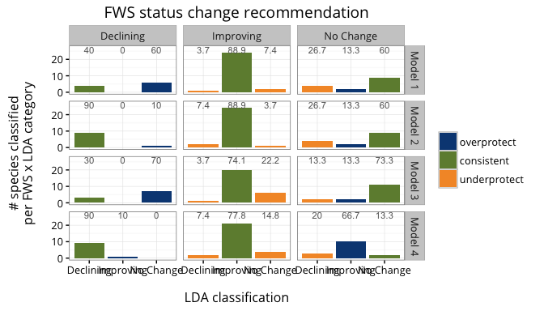